# Video 1: Bayesian A/B Testing: Introduction

### Question 1: What is Bayesian A/B Testing?

In this lecture, I'm going to introduce you the A/B testing framework in Bayesian analysis. A/B testing is used everywhere. It's useful in marketing, retail, online advertising, user experience and many other domains. If you are a data scientist working on online retail, you might want to tell your supervisor that **“the website design A is better than the website design B”**. The underlying motivation is that you want people to actually buy stuff on your website design. So your A/B testing might be testing two different versions of online store designs and you're interested in the average revenue per customer for example, because you want to go with the one that allows you to earn more money on your website. Although it's human nature to make fast decisions according to what we observe, we can't just address evidence-based actions without evidence derived from data and statistical testing such as hypothesis testing.

First, what is A/B testing? A/B testing is a kind of randomized experiment that can compare two variants of the same thing. The goal of A/B testing is to see which variant is better. It's quite flexible to define what metric we are going to test in order to pick the better variant based on numerical comparison. But generally, it's great to think of A/B testing as comparing new ideas over an established idea. For instance, if we're comparing two website designs, we might be interested in 1) comparing if changing text and background colors on a webpage leads to more sign-ups, 2) testing if using different design layouts leads to more purchases in an online store. Bayesian A/B testing is a terminology denoting an A/B testing process for two variants using the Bayesian methods. Cool!

### Question 2: Why do we need Bayesian A/B Testing to solve academic and commercial problems?

Bayesian methodology is appealing because each time we conclude an experiment when we feel confident that a new design will provide visible improvement, we can **plan the next experiment almost right away**. Remember that Bayesian model is analogous to a lifelong learner who accumulates all previous data and prior distributions as knowledge. Because of this we can **iterate quickly and run more experiments** to test new designs effectively.

For instance, when we use Bayesian A/B Testing to test different designs, we can test them many times, or test them with a large pool of clients. We can create metrics such as 1) **user engagement** - time spent on the website design, 2) **conversions** - the number of people sign-up with the website or make purchase(s), 3) **rating** - the score user rates about the clarity and easiness of reading the online content, etc. If we clearly know which design we should pick after these comparisons, we become more confident that such a design will better acquire users or generate more revenues. We are more convinced that the design we pick can better achieve our business goals. Remember that the goal of doing Bayesian A/B testing can be keeping visitors on site longer and converting website visits into sign-ups, purchases, or subscriptions, that helps generate revenues.

### Question 3: What are general considerations when doing Bayesian A/B testing experiments?

- Define motivation behind experiment - when doing A/B testing experiments we should really find the motivation behind our experiment which means you should be impartial when setting up our experiment and just passed to justify got feelings.
- Think about user segments - we also should recognize which user groups can actually benefit from the changes accompanied with the experiment. Knowing the influence to users really worth some engineering efforts.
- Don't test too many versions in parallel - because you actually want to identify the underlying pattern like what design works best for your user groups. If you test a lot of versions in parallel you might dilute the effective changes that are running.

Cool! That's a snapshot about Bayesian A/B testing. Now let's start coding in the next video!

# Video 2: Bayesian A/B Testing: Online Store Example

In this tutorial, we'll demonstrate how to use Bayesian A/B testing in an online store.

```python
# Let's first import pandas, scipy, numpy, seaborn, pymc3 and arviz packages. Those are just standard packages
# useful for data manipulation and Bayesian analysis.

import pandas as pd
from scipy import stats
import numpy as np
import seaborn as sns
import pymc3 as pm
import arviz as az

# Now let's take in the item orders and views data which is stored in the assets folder.
orders_and_views = pd.read_csv('assets/a_b_testing_for_ordering_and_viewing_items.csv')

# And take a look.
orders_and_views
```

|  | item_id | test_assignment | test_number | test_start_date |
| --- | --- | --- | --- | --- |
| 0 | 3542.0 | 0.0 | test_a | 2013-01-05 00:00:00 |
| 1 | 1981.0 | 1.0 | test_a | 2013-01-05 00:00:00 |
| 2 | 3114.0 | 0.0 | test_a | 2013-01-05 00:00:00 |
| 3 | 1295.0 | 1.0 | test_a | 2013-01-05 00:00:00 |
| 4 | 2624.0 | 0.0 | test_a | 2013-01-05 00:00:00 |
| ... | ... | ... | ... | ... |
| 13183 | 2646.0 | 0.0 | test_f | 2013-01-05 00:00:00 |
| 13184 | 1602.0 | 0.0 | test_f | 2013-01-05 00:00:00 |
| 13185 | 463.0 | 1.0 | test_f | 2013-01-05 00:00:00 |
| 13186 | 512.0 | 0.0 | test_f | 2013-01-05 00:00:00 |
| 13187 | 2944.0 | 1.0 | test_f | 2013-01-05 00:00:00 |

13188 rows × 4 columns

As you can see, the data is rich. There are more than 10,000 interactions of item views and orderings with 6 item tests. We name them test_a, test_b, test_c, test_d, test_e, and test_f. The dataset has 4 columns, showing that for each record,

- test_start_date: the test starting date,
- item_id: the product item identifier,
- test_number: the product test it belongs to and
- test_assignment: whether or not the client purchased the product.

Look at the test_assignment column. Could you imagine what are some purposes of launching 6 tests in total? I don't have the correct answer at hand. It's possible that the online retailer wants to know which online store design among the 6 alternatives leads to the best product sales in quantity. It's possible that the online retailer wants to optimize product conversion, which means the proportion of product purchase.

```python
# So the next step of data analysis might be grouping each test and compute the number of times,
# as well as the proportion of product purchase from online customers.

# We can use a very convenient pandas function called the pivot_table function to group each test group
# and compute statistics using specific aggregating functions. Here it's a typical pandas function helping
# aggregate the number and proportion of success item purchase.

# We specify the test_number as index so that the resulting table will group by each test. We'll assign the
# client purchase for each record as values, so we'll compute the successful purchases according to each test.
# First of all, we sum the purchases and save the result as a pandas DataFrame.

order_view_summary = orders_and_views.pivot_table(
    index='test_number', values='test_assignment', aggfunc=np.sum)

# We add the next column called that computes how many customers were assigned to each test group.
# So this time we switch the aggregate function to the len function that returns the number of rows
# for each test group.
order_view_summary['total'] = orders_and_views.pivot_table(
    index='test_number', values='test_assignment', aggfunc=lambda x: len(x))

# If you're not famaliar with the lambda function, the lambda function works just analogous to defining a function.

# (Read only) The whole meaning of lambda x: len(x) is that:
# it returns the length of dataset for each test_number group.
# The only difference is that the lambda function result will not cause extra memory like defining function
# because it is not saved to the variable list in Python IDE.

# Finally, we add a new column called rate, and this time we won't pass any aggregate function, and it automatically
# computes the proportion of test customers actually agreed to buy the product.
# I think is a very nice trick of data manipulation using the pivot function.
order_view_summary['rate'] = orders_and_views.pivot_table(
    values='test_assignment', index='test_number')

# After all, we can look at the summary description.
order_view_summary
```

| test_number | test_assignment | total | rate |
| --- | --- | --- | --- |
| test_a | 1086.0 | 2198.0 | 0.494086 |
| test_b | 1068.0 | 2198.0 | 0.485896 |
| test_c | 1123.0 | 2198.0 | 0.510919 |
| test_d | 1105.0 | 2198.0 | 0.502730 |
| test_e | 1078.0 | 2198.0 | 0.490446 |
| test_f | 1081.0 | 2198.0 | 0.491811 |

### Question 3: How to implement Bayesian A/B Testing in the online store example?

(Concept review: the Bayesian approach models each parameter as a random variable with some probability distribution. So we can calculate probability distributions (and thus expected values) for the parameters of interest directly.)

Before conducting Bayesian A/B testing in the online store example, we need to build a research question that specifically tells what problem you want to solve, and especially, what parameter you want to infer. You should also know your baseline which means you should actually define key metrics you are working on. Here's an example.

### Research Question:

- Using the 95% highest posterior interval, which online store designs help grow the proportion of product sales substantially in comparison to the current design (i.e. test_a)?

```python
# Without much background knowledge about how the company crafted the 6 online store designs, we can
# extract the purchase outcome for each record separately for each test design group, and name the variables
# design_a, design_b, and so on.
# This will be used as the observed data immediately when we set up the Bayesian A/B testing model in PyMC3.

design_a = orders_and_views[orders_and_views['test_number'] == 'test_a']['test_assignment']
design_b = orders_and_views[orders_and_views['test_number'] == 'test_b']['test_assignment']
design_c = orders_and_views[orders_and_views['test_number'] == 'test_c']['test_assignment']
design_d = orders_and_views[orders_and_views['test_number'] == 'test_d']['test_assignment']
design_e = orders_and_views[orders_and_views['test_number'] == 'test_e']['test_assignment']
design_f = orders_and_views[orders_and_views['test_number'] == 'test_f']['test_assignment']

# Cool! So we have six variables storing the purchase outcome for 6 designs.
```

```python
# Traditionally, we can do A/B testing directly at this point and compute the p-value for each design comparison.
# On method is to use the ttest_ind function in the scipy stats module. We'll jump right to the result since
# the code of A/B testing below just a demo for traditional method, not the Bayesian method.


# Let's take a look for all five tests.
from scipy.stats import ttest_ind

print(f'p-value design a versus b: {ttest_ind(a, b, equal_var=False, alternative="less").pvalue:.1%}')
print(f'p-value design a versus c: {ttest_ind(a, c, equal_var=False, alternative="less").pvalue:.1%}')
print(f'p-value design a versus d: {ttest_ind(a, d, equal_var=False, alternative="less").pvalue:.1%}')
print(f'p-value design a versus e: {ttest_ind(a, e, equal_var=False, alternative="less").pvalue:.1%}')
print(f'p-value design a versus f: {ttest_ind(a, f, equal_var=False, alternative="less").pvalue:.1%}')

# We see that online store design c and design d are more likely to be considered as better designs over the
# current design, while design b, design e and design f are more likely to be regarded as worse designs
# compared to the current design.

# (Read) The definition of p-value: a p-value of 13.2% with design c means that it is of 0.132 probability
# that we'll randomly observe a new design that can bring about as much improvement as or more improvement
# than the design c. The point is about randomness. If we can hardly observe a random design that can at least
# improve the sales as much as the test design, we are very confident that such new design leads to significant
# improvement. In this case, the p-value is low (mostly falls below the 0.05 threshold.)
```

```
p-value design a versus b: 70.6%
p-value design a versus c: 13.2%
p-value design a versus d: 28.3%
p-value design a versus e: 59.5%
p-value design a versus f: 56.0%
```

```python
# We don't appreciate the use of p-value as much as 20 years ago due to the sheer advancement of Bayesian methods
# thanks to the PyMC3 community.
# Now let's start creating a PyMC3 model to figure out how likely that a particular online store design
# approach can actually boost the product sales significantly.

# We create a context manager called pm.Model() and name this model as ab_testing.
with pm.Model() as ab_testing:

    # In the first step, we need to decide what prior distribution for the proportion of purchase, which is
    # kind of conversion rate. Recall that in course 1 we've showed a conversion rate example for online ads
    # and conversion rates can be between 0 and 1. So for simplicity, we can choose the Beta distribution which
    # makes sense to model the "probability of probability".

    # Remember our purpose is to determine whether a certain design improves the proportion of customer sales.
    # Therefore, for each proportion of customer purchase among the 6 designs, we assign the same prior belief.
    # Some of you may already discover that assigning same prior for each group and conduct a test is synonymous
    # to specify a fair prior we've used for hypothesis testing. And again, Bayesian A/B testing is exactly one
    # form of hypothesis testing to be clear.

    # Because we already know that using the current design_a, the success rate for product purchase
    # are slightly less than a half (from the historical data). Let's specify the probability of 0.45 in Beta
    # distribution by setting 45 for alpha and 55 for beta. I personally think its a faily strong prior distribution

    test_a = pm.Beta("test_a", alpha = 45, beta = 55)
    test_b = pm.Beta("test_b", alpha = 45, beta = 55)
    test_c = pm.Beta("test_c", alpha = 45, beta = 55)
    test_d = pm.Beta("test_d", alpha = 45, beta = 55)
    test_e = pm.Beta("test_e", alpha = 45, beta = 55)
    test_f = pm.Beta("test_f", alpha = 45, beta = 55)

    # After setting the same prior for each test design, we're confident that the difference the model shows up
    # between tests reveal the real differences in terms of customer conversion coming from the data.

    # So the next step is to define improvement in terms of proportion of purchase as a deterministic variable
    # because the subtraction of test_b and test_a - and any pair of two designs is a fixed variable, given the
    # variable is determined by test_a to test_f above.
    b_improvement = pm.Deterministic("b_improvement", test_b - test_a)
    c_improvement = pm.Deterministic("c_improvement", test_c - test_a)
    d_improvement = pm.Deterministic("d_improvement", test_d - test_a)
    e_improvement = pm.Deterministic("e_improvement", test_e - test_a)
    f_improvement = pm.Deterministic("f_improvement", test_f - test_a)

    # We now need to define the likelihood. Since conversion is binary, i.e. success and failure. There is nothing
    # in between. One straightforward way is to specify the Bernoulli variables for each binary observed data
    # because they can take only the binary values - 0 and 1. We use pm.Bernoulli for the likelihood of each design,
    # set up the variable name 'a_obs', 'b_obs' and so on, and utilize a single probability parameter from the test_a
    # up to test_f from above. In other words, we just reuse the probability
    # parameter from the prior for each test group, and use the observed option with the arrays of binary data.
    # Awesome!

    a_obs = pm.Bernoulli('a_obs', p = test_a, observed = a)
    b_obs = pm.Bernoulli('b_obs', p = test_b, observed = b)
    c_obs = pm.Bernoulli('c_obs', p = test_c, observed = c)
    d_obs = pm.Bernoulli('d_obs', p = test_d, observed = d)
    e_obs = pm.Bernoulli('e_obs', p = test_e, observed = e)
    f_obs = pm.Bernoulli('f_obs', p = test_f, observed = f)

    # We finally reached the sampling step. This time let's draw more samples for each simulation.
    # Let's return 3,000 samples for each simulation, each with 2,000 initial samples discarded
    # before the model starts to return sample values. This time I still recruit three groups of samples.
    # (What does return_inferencedata = True means?)
    trace = pm.sample(3000, chains = 3, tune = 2000, return_inferencedata = True)
```

```
Auto-assigning NUTS sampler...
Initializing NUTS using jitter+adapt_diag...
Multiprocess sampling (3 chains in 4 jobs)
NUTS: [test_f, test_e, test_d, test_c, test_b, test_a]
```

100.00% [15000/15000 00:06<00:00 Sampling 3 chains, 0 divergences]

```
Sampling 3 chains for 2_000 tune and 3_000 draw iterations (6_000 + 9_000 draws total) took 18 seconds.
```

```
array([[<AxesSubplot:title={'center':'b_improvement'}>,
        <AxesSubplot:title={'center':'c_improvement'}>,
        <AxesSubplot:title={'center':'d_improvement'}>],
       [<AxesSubplot:title={'center':'e_improvement'}>,
        <AxesSubplot:title={'center':'f_improvement'}>, <AxesSubplot:>]],
      dtype=object)
```

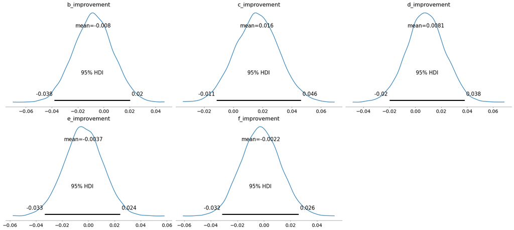

```python
# Cool! It took less than a minute to sample from the posterior distribution of the differences between designs.
# With the trace object containing the samples, we can start with the plot_posterior function in arviz to plot the
# 95% highest posterior density interval.
# It's notable that if we don't need to plot everything, we can specify the var_names. This time we only focus
# on the improvement of each design over the design a (in test_ab). So we specify 'b_improvement', 'c_improvement'
# and so on in a list, and set hdi_prob to 0.95 to plot the 95% highest posterior density interval for each design
# test.

az.plot_posterior(trace, hdi_prob = 0.95,
                  var_names = ['b_improvement', 'c_improvement', 'd_improvement',
                               'e_improvement', 'f_improvement'])

# You can see that none of the 95% highest posterior interval contains only negative or positive number.

# It means that in this experiment, we can't see visible improvement of using any of the alternative design
# (test_b, test_c, test_d, test_e, test_f) to boost the proportion of customer purchasing products online,
# assuming that the products are the same for each condition.

# In other words, we as data scientists should report to the decision makers to continue using the current design
# based on this outcome. But this by no means indicates that the new features can't help the company to gain profits.

# Therefore, despite the dissapointment about this non-exciting result, it's actually a good practice as data
# scientists to look deeper into any good sign of better design in order to create designs for the next
# iteration. We can combine several new features together in the next Bayesian A/B test and see if any substantial
# improvement will be visible compared to the current design.

# In other words, we're unlikely to draw conclusion that the current design is good enough for online store and shut
# down the research group right away.

# Looking closely to the posterior mean, we find that the some new designs are likely to operate slightly better
# than the current design. Among the six test groups, the posterior mean of
# design c and design d improvements are positive. We can argue that those improvement is anecdotal
# (it's good to make such interpretation) so we might tell the company to pay more attention to these new features
# to make new designs. But still, because none of the posterior distributions locate
# solely on the positive side, it's important to emphasize that we do not have sufficient
# evidence to establish a conclusive decision to switch to a different online store design immediately.
```